# Case Study: How Can a Wellness Technology Company Play It Smart?

## Introduction

This project is the capstone assignment for the [Google Data Analytics Professional Certificate](https://www.coursera.org/professional-certificates/google-data-analytics) program. The program prepares participants for a career in data analytics with training focused on key analytical skills (data cleaning, analysis, and visualization) and tools (Excel, SQL, R Programming, Tableau).

We’ll be investigating data sets of FitBit usage to make high-level marketing recommendations for Bellabeat—a high-tech company that manufactures health-focused smart products.

## Table of Contents

- Summary
  - Tools and Technqiues
  - Recommendations
- Guiding Questions
- Prepare Data
- Process Data
- Analysis
- References
- Contact

## Summary

[Bellabeat](https://bellabeat.com/) was founded in 2013 and has grown to become a tech-driven wellness company for women. Since 2016, they have opened offices around the globe and launched multiple products. Their apps and devices collect data on activity, sleep, stress, and reproductive health, allowing Bellabeat to empower women with knowledge about their own health and habits.

Bellabeat also offers a subscription-based membership program for users. Membership gives users 24/7 access to fully personalized guidance on nutrition, activity, sleep, health and beauty, and mindfulness based on their lifestyle and goals. There products include:

- **Bellabeat app**: The Bellabeat app provides users with health data related to their activity, sleep, stress, menstrual cycle, and mindfulness habits. This data can help users better understand their current habits and make healthy decisions. The Bellabeat app connects to their line of smart wellness products.
- **Leaf**: Bellabeat’s classic wellness tracker can be worn as a bracelet, necklace, or clip. The Leaf tracker connects to the Bellabeat app to track activity, sleep, and stress.
- **Time**: This wellness watch combines the timeless look of a classic timepiece with smart technology to track user activity, sleep, and stress. The Time watch connects to the Bellabeat app to provide you with insights into your daily wellness.
- **Spring**: This is a water bottle that tracks daily water intake using smart technology to ensure that you are appropriately hydrated throughout the day. The Spring bottle connects to the Bellabeat app to track your hydration levels.

### Guiding questions

The guiding questions for this case study are as follows:

- What are some trends in smart device usage?
- How could these trends apply to Bellabeat customers?
- How could these trends help influence Bellabeat marketing strategy?

### Tools and Techniques

The following analysis makes use of the following tools and techniques:

- R programming language and libraries; `ggplot2`, `tibble`, `tidyr`, `readr`, `purrr`, `dplyr`, `stringr`, `lubridate` and `forcats`
- Data transformations: joins, visualizations, summary statistics
- Data inspection: removal of duplicate/unnessary data, change format/datatype, verify unique values

### Recommendations

Based on the analysis, the following are three recommendations (detailed below):

- Double the Points Earned on Sundays
- Reminder Notifcations Following Active Days
- Encourage Rest Days

#### Double the Points Earned on Sundays

Based on the observations from the data, the largest trend that stands out is the increase in activity on Tuesday, Wednesday, and Thursday. Participants were most active on these days (both in terms of step count and calories burned). These also coincided with the days participants got the most sleep and spent the most time in bed. Further, we also know that Sunday is the least active day.

In order to help Bellabeat customers reach their wellness goals, it is recommended that the product team implement the ablity to add reminders when customers have lower level of activities. In particular, if we know that Sunday (and indeed Friday and Satury to some degree) is the least active day the product team could add the ability for customers to increase their wellness score by more points when they are active on Sunday. For example, perhaps activities on Sundays count for 1.5 times or 2 times the regular amount of points awarded when calculating the Wellness Score. This is intended to incentivize customers to be more active on this day.

#### Reminder Notifcations Following Active Days

We know that Tuesday, Wednesday, and Thursday are the most active days. The product team could implement notifications on the following days. These notifications could include reminders about how active the individual has been the past day (or previous days) and offer encouragement to keep staying active.

#### Encourage Rest Days

The Wellness Score in the Bellabeat app is a number calculated on a number of different factors, including activity. We know from the data that Sunday is the least active day. Perhaps, instead of encouraging individuals to be active on this day, rest should be encourage. Bellabeat takes a hollistic approach to wellness and while it is important to be active when achieiving fitness goals rest is also an important factor. In this case, perhaps the activities on Sundays (or on another rest day specified by the customer) would count for silently less so that the overall Wellness Score isn’t adversely affected.

*Continue reading for the full details of this analysis that led to these recommendations.*

## Guiding Questions

We want to analyze the smart device usage data in order to gain insights into how people are already using their smart devices and make high-level recommends for how these trends can inform Bellabeat marketing strategy. We’ll focus on the following guiding questions:

- What are some trends in smart device usage?
- How could these trends apply to Bellabeat customers?
- How could these trends help influence Bellabeat marketing strategy?

## Prepare Data

### License

The [data](https://www.kaggle.com/datasets/arashnic/fitbit?select=Fitabase+Data+4.12.16-5.12.16) is available as a public data set by [Mobius](https://www.kaggle.com/arashnic) on [Kaggle](http://www.kaggle.com/). It was generated by respondents to a distributed survey via Amazon Mechanical Turk between 03.12.2016-05.12.2016. This data is available for us under the [CC0: Public Domain License](https://creativecommons.org/publicdomain/zero/1.0/).

## Process Data

### Install/Open Libraries

```r
library("tidyverse")
```

```r
library("dplyr")
library("ggplot2")
library("lubridate")
library("corrplot")
```

### Set up Data Frames

```r
daily_activity <- read.csv("datasets/dailyActivity_merged.csv")
daily_calories <- read.csv("datasets/dailyCalories_merged.csv")
hourly_calories <- read.csv("datasets/hourlyCalories_merged.csv")
daily_steps <- read.csv("datasets/dailySteps_merged.csv")
hourly_steps <- read.csv("datasets/hourlySteps_merged.csv")
sleep_day <- read.csv("datasets/sleepDay_merged.csv")
weight <- read.csv("datasets/weightLogInfo_merged.csv")
hr <- read.csv("datasets/heartrate_seconds_merged.csv")
```

### Inspect Data Frames

For the FitBit Fitness Tracker data set we’ll focus on the following metrics for our analysis: daily activity, calories, steps, sleep, weight, and heart rate.

#### Daily Activity

```r
head(daily_activity)
```

|  | Id | ActivityDate | TotalSteps | TotalDistance | TrackerDistance | LoggedActivitiesDistance | VeryActiveDistance | ModeratelyActiveDistance | LightActiveDistance | SedentaryActiveDistance | VeryActiveMinutes | FairlyActiveMinutes | LightlyActiveMinutes | SedentaryMinutes | Calories |
| --- | --- | --- | --- | --- | --- | --- | --- | --- | --- | --- | --- | --- | --- | --- | --- |
| 1 | 1503960366 | 4/12/2016 | 13162 | 8.50 | 8.50 | 0 | 1.88 | 0.55 | 6.06 | 0 | 25 | 13 | 328 | 728 | 1985 |
| 2 | 1503960366 | 4/13/2016 | 10735 | 6.97 | 6.97 | 0 | 1.57 | 0.69 | 4.71 | 0 | 21 | 19 | 217 | 776 | 1797 |
| 3 | 1503960366 | 4/14/2016 | 10460 | 6.74 | 6.74 | 0 | 2.44 | 0.40 | 3.91 | 0 | 30 | 11 | 181 | 1218 | 1776 |
| 4 | 1503960366 | 4/15/2016 | 9762 | 6.28 | 6.28 | 0 | 2.14 | 1.26 | 2.83 | 0 | 29 | 34 | 209 | 726 | 1745 |
| 5 | 1503960366 | 4/16/2016 | 12669 | 8.16 | 8.16 | 0 | 2.71 | 0.41 | 5.04 | 0 | 36 | 10 | 221 | 773 | 1863 |
| 6 | 1503960366 | 4/17/2016 | 9705 | 6.48 | 6.48 | 0 | 3.19 | 0.78 | 2.51 | 0 | 38 | 20 | 164 | 539 | 1728 |

```r
colnames(daily_activity)
```

```
##  [1] "Id"                       "ActivityDate"
##  [3] "TotalSteps"               "TotalDistance"
##  [5] "TrackerDistance"          "LoggedActivitiesDistance"
##  [7] "VeryActiveDistance"       "ModeratelyActiveDistance"
##  [9] "LightActiveDistance"      "SedentaryActiveDistance"
## [11] "VeryActiveMinutes"        "FairlyActiveMinutes"
## [13] "LightlyActiveMinutes"     "SedentaryMinutes"
## [15] "Calories"
```

```r
sapply(daily_activity, class)
```

```
##                       Id             ActivityDate               TotalSteps
##                "numeric"              "character"                "integer"
##            TotalDistance          TrackerDistance LoggedActivitiesDistance
##                "numeric"                "numeric"                "numeric"
##       VeryActiveDistance ModeratelyActiveDistance      LightActiveDistance
##                "numeric"                "numeric"                "numeric"
##  SedentaryActiveDistance        VeryActiveMinutes      FairlyActiveMinutes
##                "numeric"                "integer"                "integer"
##     LightlyActiveMinutes         SedentaryMinutes                 Calories
##                "integer"                "integer"                "integer"
```

**Summary Statistics**

```r
daily_activity %>%
  select(TotalSteps, TotalDistance, Calories, SedentaryMinutes) %>%
  summary()
```

```
##    TotalSteps    TotalDistance       Calories    SedentaryMinutes
##  Min.   :    0   Min.   : 0.000   Min.   :   0   Min.   :   0.0
##  1st Qu.: 3790   1st Qu.: 2.620   1st Qu.:1828   1st Qu.: 729.8
##  Median : 7406   Median : 5.245   Median :2134   Median :1057.5
##  Mean   : 7638   Mean   : 5.490   Mean   :2304   Mean   : 991.2
##  3rd Qu.:10727   3rd Qu.: 7.713   3rd Qu.:2793   3rd Qu.:1229.5
##  Max.   :36019   Max.   :28.030   Max.   :4900   Max.   :1440.0
```

#### Calories

##### Daily (Calories)

```r
head(daily_calories)
```

|  | Id | ActivityDay | Calories |
| --- | --- | --- | --- |
| 1 | 1503960366 | 4/12/2016 | 1985 |
| 2 | 1503960366 | 4/13/2016 | 1797 |
| 3 | 1503960366 | 4/14/2016 | 1776 |
| 4 | 1503960366 | 4/15/2016 | 1745 |
| 5 | 1503960366 | 4/16/2016 | 1863 |
| 6 | 1503960366 | 4/17/2016 | 1728 |

```r
colnames(daily_calories)
```

```
## [1] "Id"          "ActivityDay" "Calories"
```

```r
sapply(daily_calories, class)
```

```
##          Id ActivityDay    Calories
##   "numeric" "character"   "integer"
```

**Summary Statistics**

```r
daily_calories %>%
  select(Calories) %>%
  summary()
```

```
##     Calories
##  Min.   :   0
##  1st Qu.:1828
##  Median :2134
##  Mean   :2304
##  3rd Qu.:2793
##  Max.   :4900
```

##### Hourly (Calories)

```r
head(hourly_calories)
```

|  | Id | ActivityHour | Calories |
| --- | --- | --- | --- |
| 1 | 1503960366 | 4/12/2016 12:00:00 AM | 81 |
| 2 | 1503960366 | 4/12/2016 1:00:00 AM | 61 |
| 3 | 1503960366 | 4/12/2016 2:00:00 AM | 59 |
| 4 | 1503960366 | 4/12/2016 3:00:00 AM | 47 |
| 5 | 1503960366 | 4/12/2016 4:00:00 AM | 48 |
| 6 | 1503960366 | 4/12/2016 5:00:00 AM | 48 |

```r
colnames(hourly_calories)
```

```
## [1] "Id"           "ActivityHour" "Calories"
```

```r
sapply(hourly_calories, class)
```

```
##           Id ActivityHour     Calories
##    "numeric"  "character"    "integer"
```

**Summary Statistics**

```r
hourly_calories %>%
  select(Calories) %>%
  summary()
```

```
##     Calories
##  Min.   : 42.00
##  1st Qu.: 63.00
##  Median : 83.00
##  Mean   : 97.39
##  3rd Qu.:108.00
##  Max.   :948.00
```

#### Steps

##### Daily (Steps)

```r
head(daily_steps)
```

|  | Id | ActivityDay | StepTotal |
| --- | --- | --- | --- |
| 1 | 1503960366 | 4/12/2016 | 13162 |
| 2 | 1503960366 | 4/13/2016 | 10735 |
| 3 | 1503960366 | 4/14/2016 | 10460 |
| 4 | 1503960366 | 4/15/2016 | 9762 |
| 5 | 1503960366 | 4/16/2016 | 12669 |
| 6 | 1503960366 | 4/17/2016 | 9705 |

```r
colnames(daily_steps)
```

```
## [1] "Id"          "ActivityDay" "StepTotal"
```

```r
sapply(daily_steps, class)
```

```
##          Id ActivityDay   StepTotal
##   "numeric" "character"   "integer"
```

**Summary Statistics**

```r
daily_steps %>%
  select(StepTotal) %>%
  summary()
```

```
##    StepTotal
##  Min.   :    0
##  1st Qu.: 3790
##  Median : 7406
##  Mean   : 7638
##  3rd Qu.:10727
##  Max.   :36019
```

##### Hourly (Steps)

```r
head(hourly_steps)
```

|  | Id | ActivityHour | StepTotal |
| --- | --- | --- | --- |
| 1 | 1503960366 | 4/12/2016 12:00:00 AM | 373 |
| 2 | 1503960366 | 4/12/2016 1:00:00 AM | 160 |
| 3 | 1503960366 | 4/12/2016 2:00:00 AM | 151 |
| 4 | 1503960366 | 4/12/2016 3:00:00 AM | 0 |
| 5 | 1503960366 | 4/12/2016 4:00:00 AM | 0 |
| 6 | 1503960366 | 4/12/2016 5:00:00 AM | 0 |

```r
colnames(hourly_steps)
```

```
## [1] "Id"           "ActivityHour" "StepTotal"
```

```r
sapply(hourly_steps, class)
```

```
##           Id ActivityHour    StepTotal
##    "numeric"  "character"    "integer"
```

**Summary Statistics**

```r
hourly_steps %>%
  select(StepTotal) %>%
  summary()
```

```
##    StepTotal
##  Min.   :    0.0
##  1st Qu.:    0.0
##  Median :   40.0
##  Mean   :  320.2
##  3rd Qu.:  357.0
##  Max.   :10554.0
```

#### Daily Sleep

```r
head(sleep_day)
```

|  | Id | SleepDay | TotalSleepRecords | TotalMinutesAsleep | TotalTimeInBed |
| --- | --- | --- | --- | --- | --- |
| 1 | 1503960366 | 4/12/2016 12:00:00 AM | 1 | 327 | 346 |
| 2 | 1503960366 | 4/13/2016 12:00:00 AM | 2 | 384 | 407 |
| 3 | 1503960366 | 4/15/2016 12:00:00 AM | 1 | 412 | 442 |
| 4 | 1503960366 | 4/16/2016 12:00:00 AM | 2 | 340 | 367 |
| 5 | 1503960366 | 4/17/2016 12:00:00 AM | 1 | 700 | 712 |
| 6 | 1503960366 | 4/19/2016 12:00:00 AM | 1 | 304 | 320 |

```r
colnames(sleep_day)
```

```
## [1] "Id"                 "SleepDay"           "TotalSleepRecords"
## [4] "TotalMinutesAsleep" "TotalTimeInBed"
```

```r
sapply(sleep_day, class)
```

```
##                 Id           SleepDay  TotalSleepRecords TotalMinutesAsleep
##          "numeric"        "character"          "integer"          "integer"
##     TotalTimeInBed
##          "integer"
```

**Summary Statistics**

```r
sleep_day %>%
  select(TotalMinutesAsleep, TotalTimeInBed) %>%
  summary()
```

```
##  TotalMinutesAsleep TotalTimeInBed
##  Min.   : 58.0      Min.   : 61.0
##  1st Qu.:361.0      1st Qu.:403.0
##  Median :433.0      Median :463.0
##  Mean   :419.5      Mean   :458.6
##  3rd Qu.:490.0      3rd Qu.:526.0
##  Max.   :796.0      Max.   :961.0
```

#### Weight

```r
head(weight)
```

|  | Id | Date | WeightKg | WeightPounds | Fat | BMI | IsManualReport | LogId |
| --- | --- | --- | --- | --- | --- | --- | --- | --- |
| 1 | 1503960366 | 5/2/2016 11:59:59 PM | 52.6 | 115.9631 | 22 | 22.65 | True | 1.462234e+12 |
| 2 | 1503960366 | 5/3/2016 11:59:59 PM | 52.6 | 115.9631 | NA | 22.65 | True | 1.462320e+12 |
| 3 | 1927972279 | 4/13/2016 1:08:52 AM | 133.5 | 294.3171 | NA | 47.54 | False | 1.460510e+12 |
| 4 | 2873212765 | 4/21/2016 11:59:59 PM | 56.7 | 125.0021 | NA | 21.45 | True | 1.461283e+12 |
| 5 | 2873212765 | 5/12/2016 11:59:59 PM | 57.3 | 126.3249 | NA | 21.69 | True | 1.463098e+12 |
| 6 | 4319703577 | 4/17/2016 11:59:59 PM | 72.4 | 159.6147 | 25 | 27.45 | True | 1.460938e+12 |

```r
colnames(weight)
```

```
## [1] "Id"             "Date"           "WeightKg"       "WeightPounds"
## [5] "Fat"            "BMI"            "IsManualReport" "LogId"
```

```r
sapply(weight, class)
```

```
##             Id           Date       WeightKg   WeightPounds            Fat
##      "numeric"    "character"      "numeric"      "numeric"      "integer"
##            BMI IsManualReport          LogId
##      "numeric"    "character"      "numeric"
```

**Summary Statistics**

```r
weight %>%
  select(WeightKg, WeightPounds, Fat, BMI) %>%
  summary()
```

```
##     WeightKg       WeightPounds        Fat             BMI
##  Min.   : 52.60   Min.   :116.0   Min.   :22.00   Min.   :21.45
##  1st Qu.: 61.40   1st Qu.:135.4   1st Qu.:22.75   1st Qu.:23.96
##  Median : 62.50   Median :137.8   Median :23.50   Median :24.39
##  Mean   : 72.04   Mean   :158.8   Mean   :23.50   Mean   :25.19
##  3rd Qu.: 85.05   3rd Qu.:187.5   3rd Qu.:24.25   3rd Qu.:25.56
##  Max.   :133.50   Max.   :294.3   Max.   :25.00   Max.   :47.54
##                                   NA's   :65
```

#### Heart rate

```r
head(hr)
```

|  | Id | Time | Value |
| --- | --- | --- | --- |
| 1 | 2022484408 | 4/12/2016 7:21:00 AM | 97 |
| 2 | 2022484408 | 4/12/2016 7:21:05 AM | 102 |
| 3 | 2022484408 | 4/12/2016 7:21:10 AM | 105 |
| 4 | 2022484408 | 4/12/2016 7:21:20 AM | 103 |
| 5 | 2022484408 | 4/12/2016 7:21:25 AM | 101 |
| 6 | 2022484408 | 4/12/2016 7:22:05 AM | 95 |

```r
colnames(hr)
```

```
## [1] "Id"    "Time"  "Value"
```

```r
sapply(hr, class)
```

```
##          Id        Time       Value
##   "numeric" "character"   "integer"
```

**Summary Statistics**

```r
hr %>%
  select(Value) %>%
  summary()
```

```
##      Value
##  Min.   : 36.00
##  1st Qu.: 63.00
##  Median : 73.00
##  Mean   : 77.33
##  3rd Qu.: 88.00
##  Max.   :203.00
```

### Duplicate Data

Let’s inspect our data to see if there are any duplicate information.

```r
colnames(daily_activity)
```

```
##  [1] "Id"                       "ActivityDate"
##  [3] "TotalSteps"               "TotalDistance"
##  [5] "TrackerDistance"          "LoggedActivitiesDistance"
##  [7] "VeryActiveDistance"       "ModeratelyActiveDistance"
##  [9] "LightActiveDistance"      "SedentaryActiveDistance"
## [11] "VeryActiveMinutes"        "FairlyActiveMinutes"
## [13] "LightlyActiveMinutes"     "SedentaryMinutes"
## [15] "Calories"
```

```r
colnames(daily_calories)
```

```
## [1] "Id"          "ActivityDay" "Calories"
```

```r
colnames(daily_steps)
```

```
## [1] "Id"          "ActivityDay" "StepTotal"
```

```r
colnames(hourly_calories)
```

```
## [1] "Id"           "ActivityHour" "Calories"
```

```r
colnames(hourly_steps)
```

```
## [1] "Id"           "ActivityHour" "StepTotal"
```

```r
colnames(hr)
```

```
## [1] "Id"    "Time"  "Value"
```

```r
colnames(sleep_day)
```

```
## [1] "Id"                 "SleepDay"           "TotalSleepRecords"
## [4] "TotalMinutesAsleep" "TotalTimeInBed"
```

```r
colnames(weight)
```

```
## [1] "Id"             "Date"           "WeightKg"       "WeightPounds"
## [5] "Fat"            "BMI"            "IsManualReport" "LogId"
```

```r
identical(daily_activity["Calories"], daily_calories["Calories"])
```

```
## [1] TRUE
```

```r
identical(daily_activity["TotalSteps"], daily_steps["StepTotal"])
```

```
## [1] FALSE
```

A `TRUE` value is returned for the ‘Calories’ columns of ‘daily_activity’ and ‘daily_calories’, thus both columns in the data frames have identical values.

For ‘daily_activity’ and ‘daily_steps’ the columns for the number of steps returns a `FALSE` value indicating the values are **not** the same in these two coloumns. **However, when we view the data frames (see below), at first glance, it looks like the values are identical. They have have the same number of distinct rows for ‘Id’.**

```r
head(daily_activity)
```

|  | Id | ActivityDate | TotalSteps | TotalDistance | TrackerDistance | LoggedActivitiesDistance | VeryActiveDistance | ModeratelyActiveDistance | LightActiveDistance | SedentaryActiveDistance | VeryActiveMinutes | FairlyActiveMinutes | LightlyActiveMinutes | SedentaryMinutes | Calories |
| --- | --- | --- | --- | --- | --- | --- | --- | --- | --- | --- | --- | --- | --- | --- | --- |
| 1 | 1503960366 | 4/12/2016 | 13162 | 8.50 | 8.50 | 0 | 1.88 | 0.55 | 6.06 | 0 | 25 | 13 | 328 | 728 | 1985 |
| 2 | 1503960366 | 4/13/2016 | 10735 | 6.97 | 6.97 | 0 | 1.57 | 0.69 | 4.71 | 0 | 21 | 19 | 217 | 776 | 1797 |
| 3 | 1503960366 | 4/14/2016 | 10460 | 6.74 | 6.74 | 0 | 2.44 | 0.40 | 3.91 | 0 | 30 | 11 | 181 | 1218 | 1776 |
| 4 | 1503960366 | 4/15/2016 | 9762 | 6.28 | 6.28 | 0 | 2.14 | 1.26 | 2.83 | 0 | 29 | 34 | 209 | 726 | 1745 |
| 5 | 1503960366 | 4/16/2016 | 12669 | 8.16 | 8.16 | 0 | 2.71 | 0.41 | 5.04 | 0 | 36 | 10 | 221 | 773 | 1863 |
| 6 | 1503960366 | 4/17/2016 | 9705 | 6.48 | 6.48 | 0 | 3.19 | 0.78 | 2.51 | 0 | 38 | 20 | 164 | 539 | 1728 |

```r
nrow(daily_activity)
```

```
## [1] 940
```

```r
head(daily_steps)
```

|  | Id | ActivityDay | StepTotal |
| --- | --- | --- | --- |
| 1 | 1503960366 | 4/12/2016 | 13162 |
| 2 | 1503960366 | 4/13/2016 | 10735 |
| 3 | 1503960366 | 4/14/2016 | 10460 |
| 4 | 1503960366 | 4/15/2016 | 9762 |
| 5 | 1503960366 | 4/16/2016 | 12669 |
| 6 | 1503960366 | 4/17/2016 | 9705 |

```r
nrow(daily_steps)
```

```
## [1] 940
```

This seems strange, so let’s compare the summary statistics and plot the data to see if they are indeed the same.

#### Summary Statistics: Daily Activity and Daily Steps

```r
daily_activity %>%
  select(TotalSteps) %>%
  summary()
```

```
##    TotalSteps
##  Min.   :    0
##  1st Qu.: 3790
##  Median : 7406
##  Mean   : 7638
##  3rd Qu.:10727
##  Max.   :36019
```

```r
daily_steps %>%
  select(StepTotal) %>%
  summary()
```

```
##    StepTotal
##  Min.   :    0
##  1st Qu.: 3790
##  Median : 7406
##  Mean   : 7638
##  3rd Qu.:10727
##  Max.   :36019
```

**Observations**

Summary statistics are identical.

#### Comparision Plots

##### ‘TotalSteps’ from ‘daily_activity’

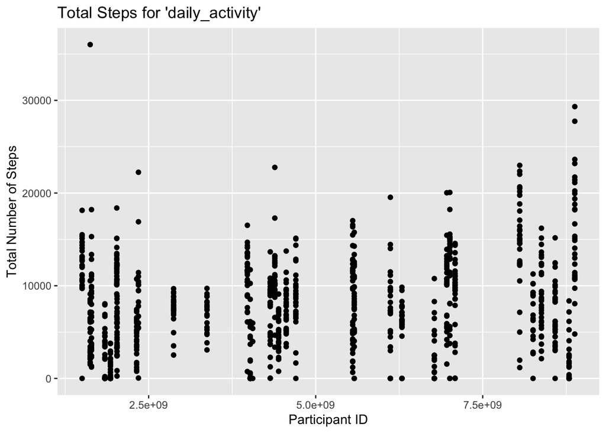

```r
ggplot(data = daily_activity) +
  geom_point(mapping = aes(x = Id, y = TotalSteps)) +
  xlab("Participant ID") +
  ylab("Total Number of Steps") +
  ggtitle("Total Steps for 'daily_activity'")
```

##### ‘StepTotal’ from ‘daily_steps’

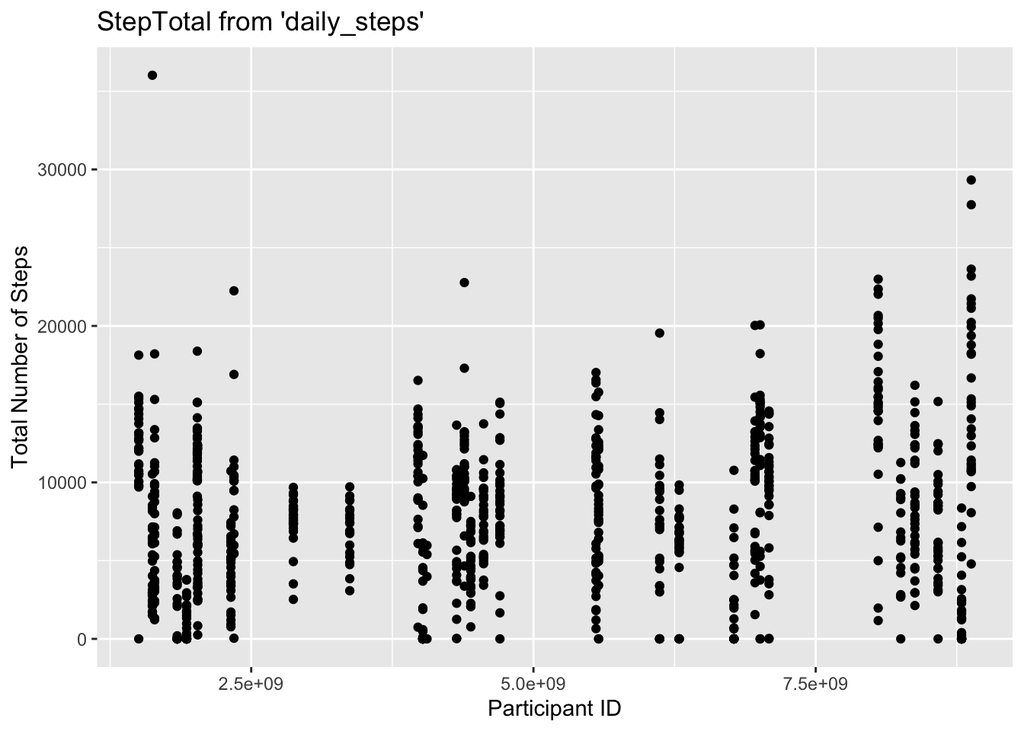

```r
ggplot(data = daily_steps) +
  geom_point(mapping = aes(x = Id, y = StepTotal)) +
  xlab("Participant ID") +
  ylab("Total Number of Steps") +
  ggtitle("StepTotal from 'daily_steps'")
```

**Observations**

Plot data is also identical for the columns ‘TotalSteps’ and ‘StepTotal’ for the data in ‘daily_activity’ and ‘daily_steps’, respectively. I’m not sure why the ‘identical()’ function returned a ‘FALSE’ statement previously, but let’s confirm using the ‘all.equal()’ function.

#### All Equal?

```r
all.equal(daily_activity$TotalSteps, daily_steps$StepTotal)
```

```
## [1] TRUE
```

### Distinct Data

Let’s inspect the data for unique values.

```r
n_distinct(daily_activity$Id)
```

```
## [1] 33
```

```r
n_distinct(daily_steps$Id)
```

```
## [1] 33
```

```r
n_distinct(daily_calories$Id)
```

```
## [1] 33
```

```r
n_distinct(hourly_calories$Id)
```

```
## [1] 33
```

```r
n_distinct(hourly_steps$Id)
```

```
## [1] 33
```

```r
n_distinct(hr$Id)
```

```
## [1] 14
```

```r
n_distinct(sleep_day$Id)
```

```
## [1] 24
```

```r
n_distinct(weight$Id)
```

```
## [1] 8
```

The following data frames have the same number of distinct rows: ‘daily_activity’, ‘daily_steps’, ‘daily_calories’, ‘hourly_calories’, and ‘hourly_steps’. However, the remaining data frames (‘hr’, ‘sleep_day’, and ‘weight’) have different distinct values. This could indicate that these data sets contained fewer participants or fewer measurements for those values.

### Missing Data

Let’s check to see if there’s any missing data values.

```r
any(is.na(daily_activity))
```

```
## [1] FALSE
```

```r
any(is.na(daily_calories))
```

```
## [1] FALSE
```

```r
any(is.na(daily_steps))
```

```
## [1] FALSE
```

```r
any(is.na(hourly_calories))
```

```
## [1] FALSE
```

```r
any(is.na(hourly_steps))
```

```
## [1] FALSE
```

```r
any(is.na(hr))
```

```
## [1] FALSE
```

```r
any(is.na(sleep_day))
```

```
## [1] FALSE
```

```r
any(is.na(weight))
```

```
## [1] TRUE
```

There are some NA values in ‘weight’ let’s take a closer look:

```r
is.na(weight)
```

```
##          Id  Date WeightKg WeightPounds   Fat   BMI IsManualReport LogId
##  [1,] FALSE FALSE    FALSE        FALSE FALSE FALSE          FALSE FALSE
##  [2,] FALSE FALSE    FALSE        FALSE  TRUE FALSE          FALSE FALSE
##  [3,] FALSE FALSE    FALSE        FALSE  TRUE FALSE          FALSE FALSE
##  [4,] FALSE FALSE    FALSE        FALSE  TRUE FALSE          FALSE FALSE
##  [5,] FALSE FALSE    FALSE        FALSE  TRUE FALSE          FALSE FALSE
##  [6,] FALSE FALSE    FALSE        FALSE FALSE FALSE          FALSE FALSE
##  [7,] FALSE FALSE    FALSE        FALSE  TRUE FALSE          FALSE FALSE
##  [8,] FALSE FALSE    FALSE        FALSE  TRUE FALSE          FALSE FALSE
##  [9,] FALSE FALSE    FALSE        FALSE  TRUE FALSE          FALSE FALSE
## [10,] FALSE FALSE    FALSE        FALSE  TRUE FALSE          FALSE FALSE
## [11,] FALSE FALSE    FALSE        FALSE  TRUE FALSE          FALSE FALSE
## [12,] FALSE FALSE    FALSE        FALSE  TRUE FALSE          FALSE FALSE
## [13,] FALSE FALSE    FALSE        FALSE  TRUE FALSE          FALSE FALSE
## [14,] FALSE FALSE    FALSE        FALSE  TRUE FALSE          FALSE FALSE
```

[output cut: 53 more lines]

**Observations**

I’m not sure what the ‘Fat’ column is measuring (body fat percentage?), but since there are only two values provided for the entire column it’s likely that this column will need to be excluded during the analysis.

### Final Observations from the Data Inspection

The data frames ‘daily_activity’ and ‘daily_calories’ both have a column called ‘Calories’ and this is the same data. We can ignore the data frame ‘daily_calories’ since it’s repetitive.

Some of the columns have date/time data stored as a `chr` (character strings) and will need to change it to a proper datetime format:

- The following data sets have a *date* column that needs to change: ‘daily_activity’, ‘daily_calories’, and ‘daily_steps’
- The following data sets have a *datetime* column that needs to change: ‘hourly_calories’, ‘hourly_steps’, ‘hr’, ‘sleep_day’, and ‘weight’.

Further, the following data frames have a column called ‘Id’ with identical data: ‘daily_activity’, ‘daily_calories’, ‘daily_steps’, ‘hourly_calories’, and ‘hourly_steps’. This is useful if it becomes necessary to combine the data.

### Cleaning & Formatting the Data

#### Cleaning Checklist

After inspecting the data, the following issues need to be resolved before the analysis can begin:

- Remove ‘Fat’ column from ‘weight’ data frame
- Change date/time columns (e.g., ‘ActivityDate’) from `chr` to a datetime format
- Merge datasets along the ‘Id’ parameter for easy access and analysis

#### Drop Unnecessary Data

It was determined that the ‘Fat’ column in the ‘weight’ data frame was not needed (since it only has two values). We’ll create a new data frame without it.

```r
# create subset
wt <- subset(weight, select = -c(Fat))
# check that column was removed
colnames(wt)
```

```
## [1] "Id"             "Date"           "WeightKg"       "WeightPounds"
## [5] "BMI"            "IsManualReport" "LogId"
```

#### Change Datatype

##### Reformat Date Columns

The following data sets have a *date* column that needs to be reformatted: ‘daily_activity’, ‘daily_calories’, and ‘daily_steps’.

```r
# convert col 'ActivityDate' in 'daily_activity'
daily_activity$Date <- as.POSIXct(daily_activity$ActivityDate, format = "%m/%d/%Y")
# confirm accurate conversion
typeof(daily_activity$Date)
```

```
## [1] "double"
```

```r
# convert col 'ActivityDay' in 'daily_calories'
daily_calories$Date <- as.POSIXct(daily_calories$ActivityDay, format = "%m/%d/%Y")
# confirm accurate conversion
typeof(daily_calories$Date)
```

```
## [1] "double"
```

```r
# convert col 'ActivityDay' in 'daily_steps'
daily_steps$Date <- as.POSIXct(daily_steps$ActivityDay, format = "%m/%d/%Y")
# confirm accurate conversion
typeof(daily_steps$Date)
```

```
## [1] "double"
```

```r
# convert col 'Date' in 'weight'
weight$DateTime <- as.POSIXct(weight$Date, format = "%m/%d/%Y")
# confirm accurate conversion
typeof(weight$DateTime)
```

```
## [1] "double"
```

##### Add column for day of the week

Now that we have the new column with the date, let’s create a column for the day of the week too. This will allow us to anlayze the usage by the day of the week and see if there are any interesting patterns that emege.

```r
daily_activity$WeekDay <- wday(daily_activity$Date, label = TRUE, abbr = TRUE)
head(daily_activity)
```

|  | Id | ActivityDate | TotalSteps | TotalDistance | TrackerDistance | LoggedActivitiesDistance | VeryActiveDistance | ModeratelyActiveDistance | LightActiveDistance | SedentaryActiveDistance | VeryActiveMinutes | FairlyActiveMinutes | LightlyActiveMinutes | SedentaryMinutes | Calories | Date | WeekDay |
| --- | --- | --- | --- | --- | --- | --- | --- | --- | --- | --- | --- | --- | --- | --- | --- | --- | --- |
| 1 | 1503960366 | 4/12/2016 | 13162 | 8.50 | 8.50 | 0 | 1.88 | 0.55 | 6.06 | 0 | 25 | 13 | 328 | 728 | 1985 | 2016-04-12 | Tue |
| 2 | 1503960366 | 4/13/2016 | 10735 | 6.97 | 6.97 | 0 | 1.57 | 0.69 | 4.71 | 0 | 21 | 19 | 217 | 776 | 1797 | 2016-04-13 | Wed |
| 3 | 1503960366 | 4/14/2016 | 10460 | 6.74 | 6.74 | 0 | 2.44 | 0.40 | 3.91 | 0 | 30 | 11 | 181 | 1218 | 1776 | 2016-04-14 | Thu |
| 4 | 1503960366 | 4/15/2016 | 9762 | 6.28 | 6.28 | 0 | 2.14 | 1.26 | 2.83 | 0 | 29 | 34 | 209 | 726 | 1745 | 2016-04-15 | Fri |
| 5 | 1503960366 | 4/16/2016 | 12669 | 8.16 | 8.16 | 0 | 2.71 | 0.41 | 5.04 | 0 | 36 | 10 | 221 | 773 | 1863 | 2016-04-16 | Sat |
| 6 | 1503960366 | 4/17/2016 | 9705 | 6.48 | 6.48 | 0 | 3.19 | 0.78 | 2.51 | 0 | 38 | 20 | 164 | 539 | 1728 | 2016-04-17 | Sun |

```r
daily_calories$WeekDay <- wday(daily_calories$Date, label = TRUE, abbr = TRUE)
head(daily_calories)
```

|  | Id | ActivityDay | Calories | Date | WeekDay |
| --- | --- | --- | --- | --- | --- |
| 1 | 1503960366 | 4/12/2016 | 1985 | 2016-04-12 | Tue |
| 2 | 1503960366 | 4/13/2016 | 1797 | 2016-04-13 | Wed |
| 3 | 1503960366 | 4/14/2016 | 1776 | 2016-04-14 | Thu |
| 4 | 1503960366 | 4/15/2016 | 1745 | 2016-04-15 | Fri |
| 5 | 1503960366 | 4/16/2016 | 1863 | 2016-04-16 | Sat |
| 6 | 1503960366 | 4/17/2016 | 1728 | 2016-04-17 | Sun |

```r
daily_steps$WeekDay <- wday(daily_steps$Date, label = TRUE, abbr = TRUE)
head(daily_steps)
```

|  | Id | ActivityDay | StepTotal | Date | WeekDay |
| --- | --- | --- | --- | --- | --- |
| 1 | 1503960366 | 4/12/2016 | 13162 | 2016-04-12 | Tue |
| 2 | 1503960366 | 4/13/2016 | 10735 | 2016-04-13 | Wed |
| 3 | 1503960366 | 4/14/2016 | 10460 | 2016-04-14 | Thu |
| 4 | 1503960366 | 4/15/2016 | 9762 | 2016-04-15 | Fri |
| 5 | 1503960366 | 4/16/2016 | 12669 | 2016-04-16 | Sat |
| 6 | 1503960366 | 4/17/2016 | 9705 | 2016-04-17 | Sun |

##### Create Datetime Column

The following data sets have a *datetime* column that needs to be reformatted: ‘hourly_calories’, ‘hourly_steps’, ‘hr’, ‘sleep_day’, and ‘wt’.

```r
# convert col 'ActivityHour' in 'hourly_calories'
hourly_calories$ActHour <- as.POSIXct(hourly_calories$ActivityHour, format = "%m/%d/%Y %I:%M:%S %p")
# confirm accurate conversion
typeof(hourly_calories$ActHour)
```

```
## [1] "double"
```

```r
# convert col 'ActivityHour' in 'hourly_steps'
hourly_steps$ActHour <- as.POSIXct(hourly_steps$ActivityHour, format = "%m/%d/%Y %I:%M:%S %p")
# confirm accurate conversion
typeof(hourly_steps$ActHour)
```

```
## [1] "double"
```

```r
# convert col 'Time' in 'hr'
hr$DateTime <- as.POSIXct(hr$Time, format = "%m/%d/%Y %I:%M:%S %p")
# confirm accurate conversion
typeof(hr$DateTime)
```

```
## [1] "double"
```

```r
# convert col 'SleepDay' in 'sleep_day'
sleep_day$DateTime <- as.POSIXct(sleep_day$SleepDay, format = "%m/%d/%Y %I:%M:%S %p")
# confirm accurate conversion
typeof(sleep_day$DateTime)
```

```
## [1] "double"
```

```r
# convert col 'Date' in 'wt'
wt$DateTime <- as.POSIXct(wt$Date, format = "%m/%d/%Y %I:%M:%S %p")
# confirm accurate conversion
typeof(wt$DateTime)
```

```
## [1] "double"
```

```r
wt$WeekDay <- wday(wt$DateTime, label = TRUE, abbr = TRUE)
head(wt)
```

|  | Id | Date | WeightKg | WeightPounds | BMI | IsManualReport | LogId | DateTime | WeekDay |
| --- | --- | --- | --- | --- | --- | --- | --- | --- | --- |
| 1 | 1503960366 | 5/2/2016 11:59:59 PM | 52.6 | 115.9631 | 22.65 | True | 1.462234e+12 | 2016-05-02 23:59:59 | Mon |
| 2 | 1503960366 | 5/3/2016 11:59:59 PM | 52.6 | 115.9631 | 22.65 | True | 1.462320e+12 | 2016-05-03 23:59:59 | Tue |
| 3 | 1927972279 | 4/13/2016 1:08:52 AM | 133.5 | 294.3171 | 47.54 | False | 1.460510e+12 | 2016-04-13 01:08:52 | Wed |
| 4 | 2873212765 | 4/21/2016 11:59:59 PM | 56.7 | 125.0021 | 21.45 | True | 1.461283e+12 | 2016-04-21 23:59:59 | Thu |
| 5 | 2873212765 | 5/12/2016 11:59:59 PM | 57.3 | 126.3249 | 21.69 | True | 1.463098e+12 | 2016-05-12 23:59:59 | Thu |
| 6 | 4319703577 | 4/17/2016 11:59:59 PM | 72.4 | 159.6147 | 27.45 | True | 1.460938e+12 | 2016-04-17 23:59:59 | Sun |

##### Create Hour Column

Similarly to creating a day of the week column, we want to create an hour column for these data sets so that we can analyze the data usage by hour.

```r
hourly_calories$Hour <- hour(hourly_calories$ActHour)
head(hourly_calories)
```

|  | Id | ActivityHour | Calories | ActHour | Hour |
| --- | --- | --- | --- | --- | --- |
| 1 | 1503960366 | 4/12/2016 12:00:00 AM | 81 | 2016-04-12 00:00:00 | 0 |
| 2 | 1503960366 | 4/12/2016 1:00:00 AM | 61 | 2016-04-12 01:00:00 | 1 |
| 3 | 1503960366 | 4/12/2016 2:00:00 AM | 59 | 2016-04-12 02:00:00 | 2 |
| 4 | 1503960366 | 4/12/2016 3:00:00 AM | 47 | 2016-04-12 03:00:00 | 3 |
| 5 | 1503960366 | 4/12/2016 4:00:00 AM | 48 | 2016-04-12 04:00:00 | 4 |
| 6 | 1503960366 | 4/12/2016 5:00:00 AM | 48 | 2016-04-12 05:00:00 | 5 |

```r
hourly_steps$Hour <- hour(hourly_calories$ActHour)
head(hourly_steps)
```

|  | Id | ActivityHour | StepTotal | ActHour | Hour |
| --- | --- | --- | --- | --- | --- |
| 1 | 1503960366 | 4/12/2016 12:00:00 AM | 373 | 2016-04-12 00:00:00 | 0 |
| 2 | 1503960366 | 4/12/2016 1:00:00 AM | 160 | 2016-04-12 01:00:00 | 1 |
| 3 | 1503960366 | 4/12/2016 2:00:00 AM | 151 | 2016-04-12 02:00:00 | 2 |
| 4 | 1503960366 | 4/12/2016 3:00:00 AM | 0 | 2016-04-12 03:00:00 | 3 |
| 5 | 1503960366 | 4/12/2016 4:00:00 AM | 0 | 2016-04-12 04:00:00 | 4 |
| 6 | 1503960366 | 4/12/2016 5:00:00 AM | 0 | 2016-04-12 05:00:00 | 5 |

```r
hr$Hour <- hour(hr$DateTime)
head(hr)
```

|  | Id | Time | Value | DateTime | Hour |
| --- | --- | --- | --- | --- | --- |
| 1 | 2022484408 | 4/12/2016 7:21:00 AM | 97 | 2016-04-12 07:21:00 | 7 |
| 2 | 2022484408 | 4/12/2016 7:21:05 AM | 102 | 2016-04-12 07:21:05 | 7 |
| 3 | 2022484408 | 4/12/2016 7:21:10 AM | 105 | 2016-04-12 07:21:10 | 7 |
| 4 | 2022484408 | 4/12/2016 7:21:20 AM | 103 | 2016-04-12 07:21:20 | 7 |
| 5 | 2022484408 | 4/12/2016 7:21:25 AM | 101 | 2016-04-12 07:21:25 | 7 |
| 6 | 2022484408 | 4/12/2016 7:22:05 AM | 95 | 2016-04-12 07:22:05 | 7 |

```r
wt$Hour <- hour(wt$DateTime)
head(wt)
```

|  | Id | Date | WeightKg | WeightPounds | BMI | IsManualReport | LogId | DateTime | WeekDay | Hour |
| --- | --- | --- | --- | --- | --- | --- | --- | --- | --- | --- |
| 1 | 1503960366 | 5/2/2016 11:59:59 PM | 52.6 | 115.9631 | 22.65 | True | 1.462234e+12 | 2016-05-02 23:59:59 | Mon | 23 |
| 2 | 1503960366 | 5/3/2016 11:59:59 PM | 52.6 | 115.9631 | 22.65 | True | 1.462320e+12 | 2016-05-03 23:59:59 | Tue | 23 |
| 3 | 1927972279 | 4/13/2016 1:08:52 AM | 133.5 | 294.3171 | 47.54 | False | 1.460510e+12 | 2016-04-13 01:08:52 | Wed | 1 |
| 4 | 2873212765 | 4/21/2016 11:59:59 PM | 56.7 | 125.0021 | 21.45 | True | 1.461283e+12 | 2016-04-21 23:59:59 | Thu | 23 |
| 5 | 2873212765 | 5/12/2016 11:59:59 PM | 57.3 | 126.3249 | 21.69 | True | 1.463098e+12 | 2016-05-12 23:59:59 | Thu | 23 |
| 6 | 4319703577 | 4/17/2016 11:59:59 PM | 72.4 | 159.6147 | 27.45 | True | 1.460938e+12 | 2016-04-17 23:59:59 | Sun | 23 |

#### Merge Data Sets

The final step in our cleaning phase is to merge the data sets along the ‘Id’ parameter. This will give us a combined data set which we can easily access and analyze.

```r
# combine data frames
stats_daily <- merge(sleep_day, daily_activity, by = "Id")
stats_hourly <- hourly_calories %>%
  select(Id, Calories) %>%
  left_join(hourly_steps, by = "Id")
# check for missing values
any(is.na(stats_daily))
```

```
## [1] FALSE
```

```r
any(is.na(stats_hourly))
```

```
## [1] FALSE
```

```r
# confirm combination
head(stats_daily)
```

|  | Id | SleepDay | TotalSleepRecords | TotalMinutesAsleep | TotalTimeInBed | DateTime | ActivityDate | TotalSteps | TotalDistance | TrackerDistance | LoggedActivitiesDistance | VeryActiveDistance | ModeratelyActiveDistance | LightActiveDistance | SedentaryActiveDistance | VeryActiveMinutes | FairlyActiveMinutes | LightlyActiveMinutes | SedentaryMinutes | Calories | Date | WeekDay |
| --- | --- | --- | --- | --- | --- | --- | --- | --- | --- | --- | --- | --- | --- | --- | --- | --- | --- | --- | --- | --- | --- | --- |
| 1 | 1503960366 | 4/12/2016 12:00:00 AM | 1 | 327 | 346 | 2016-04-12 | 5/7/2016 | 11992 | 7.71 | 7.71 | 0 | 2.46 | 2.12 | 3.13 | 0 | 37 | 46 | 175 | 833 | 1821 | 2016-05-07 | Sat |
| 2 | 1503960366 | 4/12/2016 12:00:00 AM | 1 | 327 | 346 | 2016-04-12 | 5/6/2016 | 12159 | 8.03 | 8.03 | 0 | 1.97 | 0.25 | 5.81 | 0 | 24 | 6 | 289 | 754 | 1896 | 2016-05-06 | Fri |
| 3 | 1503960366 | 4/12/2016 12:00:00 AM | 1 | 327 | 346 | 2016-04-12 | 5/1/2016 | 10602 | 6.81 | 6.81 | 0 | 2.29 | 1.60 | 2.92 | 0 | 33 | 35 | 246 | 730 | 1820 | 2016-05-01 | Sun |
| 4 | 1503960366 | 4/12/2016 12:00:00 AM | 1 | 327 | 346 | 2016-04-12 | 4/30/2016 | 14673 | 9.25 | 9.25 | 0 | 3.56 | 1.42 | 4.27 | 0 | 52 | 34 | 217 | 712 | 1947 | 2016-04-30 | Sat |
| 5 | 1503960366 | 4/12/2016 12:00:00 AM | 1 | 327 | 346 | 2016-04-12 | 4/12/2016 | 13162 | 8.50 | 8.50 | 0 | 1.88 | 0.55 | 6.06 | 0 | 25 | 13 | 328 | 728 | 1985 | 2016-04-12 | Tue |
| 6 | 1503960366 | 4/12/2016 12:00:00 AM | 1 | 327 | 346 | 2016-04-12 | 4/13/2016 | 10735 | 6.97 | 6.97 | 0 | 1.57 | 0.69 | 4.71 | 0 | 21 | 19 | 217 | 776 | 1797 | 2016-04-13 | Wed |

```r
head(stats_hourly)
```

|  | Id | Calories | ActivityHour | StepTotal | ActHour | Hour |
| --- | --- | --- | --- | --- | --- | --- |
| 1 | 1503960366 | 81 | 4/12/2016 12:00:00 AM | 373 | 2016-04-12 00:00:00 | 0 |
| 2 | 1503960366 | 81 | 4/12/2016 1:00:00 AM | 160 | 2016-04-12 01:00:00 | 1 |
| 3 | 1503960366 | 81 | 4/12/2016 2:00:00 AM | 151 | 2016-04-12 02:00:00 | 2 |
| 4 | 1503960366 | 81 | 4/12/2016 3:00:00 AM | 0 | 2016-04-12 03:00:00 | 3 |
| 5 | 1503960366 | 81 | 4/12/2016 4:00:00 AM | 0 | 2016-04-12 04:00:00 | 4 |
| 6 | 1503960366 | 81 | 4/12/2016 5:00:00 AM | 0 | 2016-04-12 05:00:00 | 5 |

Now that we’ve successfully combined the data, we’ll focus our analysis on the following data frames: ‘stats_daily’, ‘stats_hourly’, ‘hr’, and ‘wt’.

## Analysis

### Visualizations

We’ll start by setting plot variables for each of data frames we plan to visualize. This will make it easier to access the plot our data.

```r
plt_daily <- ggplot(data = stats_daily)
plt_hourly <- ggplot(data = stats_hourly)
plt_hr <- ggplot(data = hr)
plt_wt <- ggplot(data = wt)
```

### Heart Rate

Let’s take a look at how heart rate (hr) changes throughout the course of the day.

#### Boxplot: Hour vs. Heart Rate

This plot displays each hour of the day compared to the 5-number summary distribution (box plot) of heart rate measurements from participants.

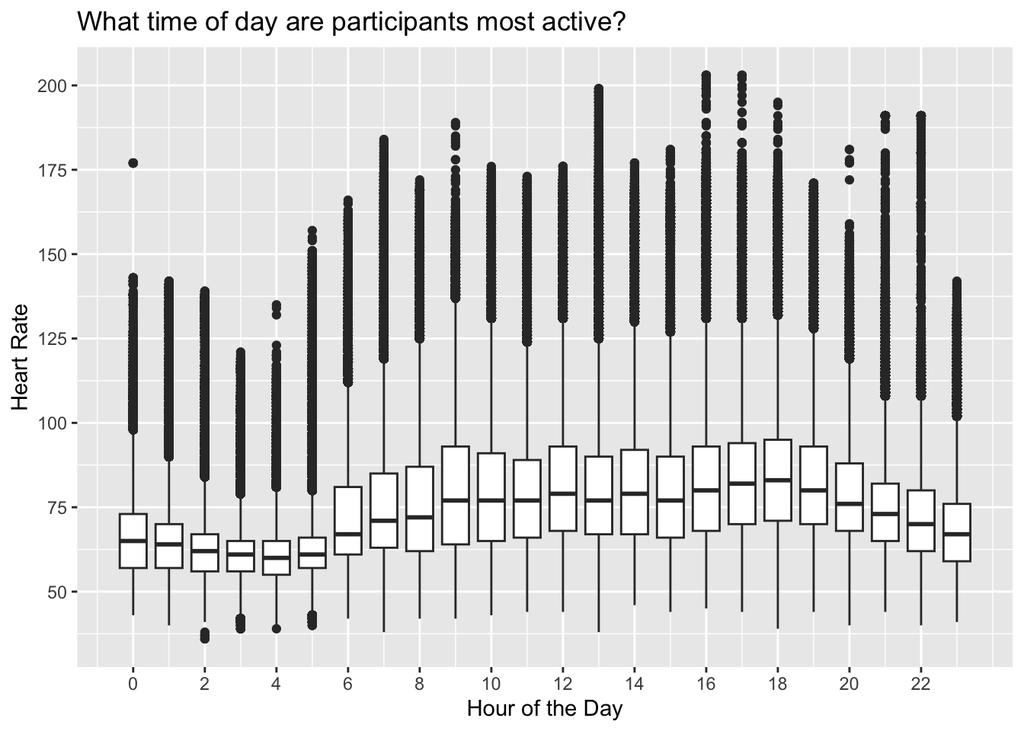

```r
plt_hr +
  geom_boxplot(mapping = aes(group = Hour, x = Hour, y = Value)) +
  xlab("Hour of the Day") +
  ylab("Heart Rate") +
  scale_x_continuous(breaks = seq(0, 23, 2)) +
  scale_y_continuous(breaks = seq(0, 200, 25)) +
  ggtitle("What time of day are participants most active?")
```

**Observations**

As to be expected, the heart rates of participants are more active during that day than at night. Interestingly, we do see outliers of both high and low heart rates throughout the day. This shows that while most people follow expectations of elevating their heart rates (presumably through exercise) at normal times of days, there are those who do not follow this expectation.

### Weight

#### Histogram: Weight

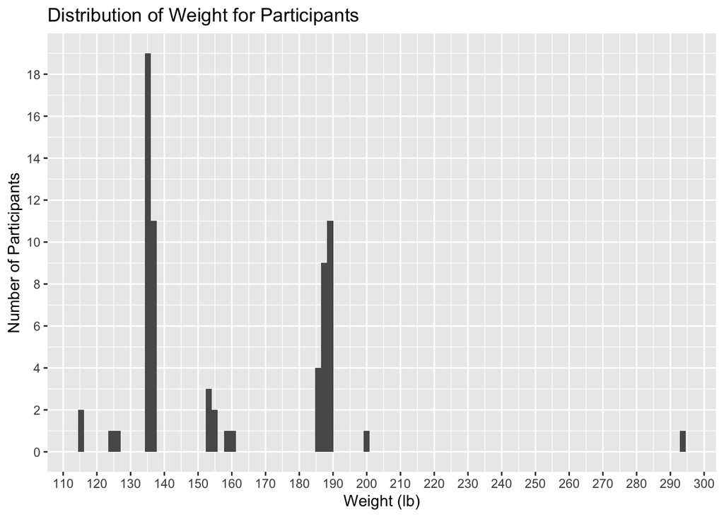

```r
plt_wt +
  geom_histogram(mapping = aes(x = WeightPounds), bins = 100) +
  xlab("Weight (lb)") +
  ylab("Number of Participants") +
  scale_x_continuous(breaks = seq(0, 300, 10)) +
  scale_y_continuous(breaks = seq(0, 20, 2)) +
  ggtitle("Distribution of Weight for Participants")
```

**Observations** Most individuals fall between 100 and 200 pounds, however there is one individual who weighs 300 pounds.

#### Scatter Plot: Weight vs. BMI

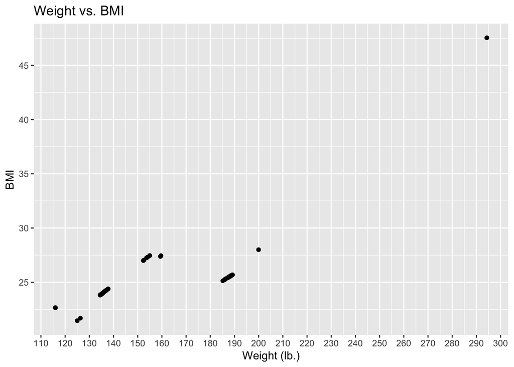

```r
plt_wt +
  geom_point(mapping = aes(x = WeightPounds, y = BMI)) +
  xlab("Weight (lb.)") +
  ylab("BMI") +
  scale_x_continuous(breaks = seq(0, 300, 10)) +
  scale_y_continuous(breaks = seq(0, 50, 5)) +
  ggtitle("Weight vs. BMI")
```

**Observations**

As expected, individuals with a higher weight also have a higher BMI.

#### Weight Changes Tracked Over Time

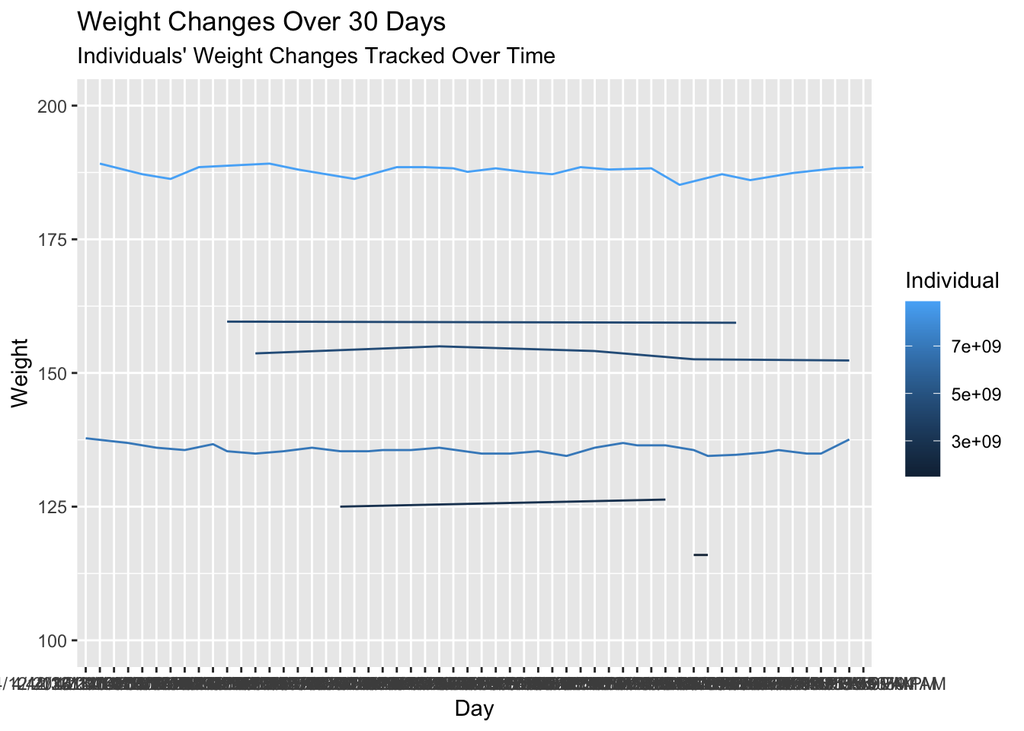

```r
plt_wt +
  geom_line(mapping = aes(x = Date, y = WeightPounds, group = Id, color = Id)) +
  labs(x = "Day", y = "Weight", title = "Weight Changes Over 30 Days", subtitle = "Individuals' Weight Changes Tracked Over Time", color = "Individual") +
  coord_cartesian(ylim = c(100, 200))
```

**Observations**

Unfortunately, only a limited number of participants successfully tracked their weight changes over the 30 day period. However, we do see that during this period for those who tracked their changes their weight hardly changed during this time period.

While more data is needed to fully understand how weight changes over a 30-day time period, this could be useful information for individuals when setting their expectations around their weight goals.

### Daily Activity

#### Steps

##### Bar Graph: Week Day vs. Steps

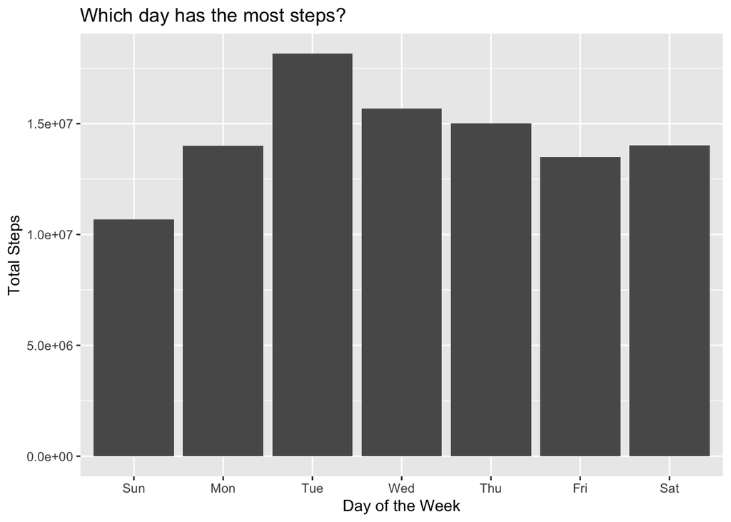

```r
plt_daily +
  geom_col(mapping = aes(x = WeekDay, y = TotalSteps)) +
  xlab("Day of the Week") +
  ylab("Total Steps") +
  ggtitle("Which day has the most steps?")
```

**Observations**

##### Boxplot: Week Day vs. Steps

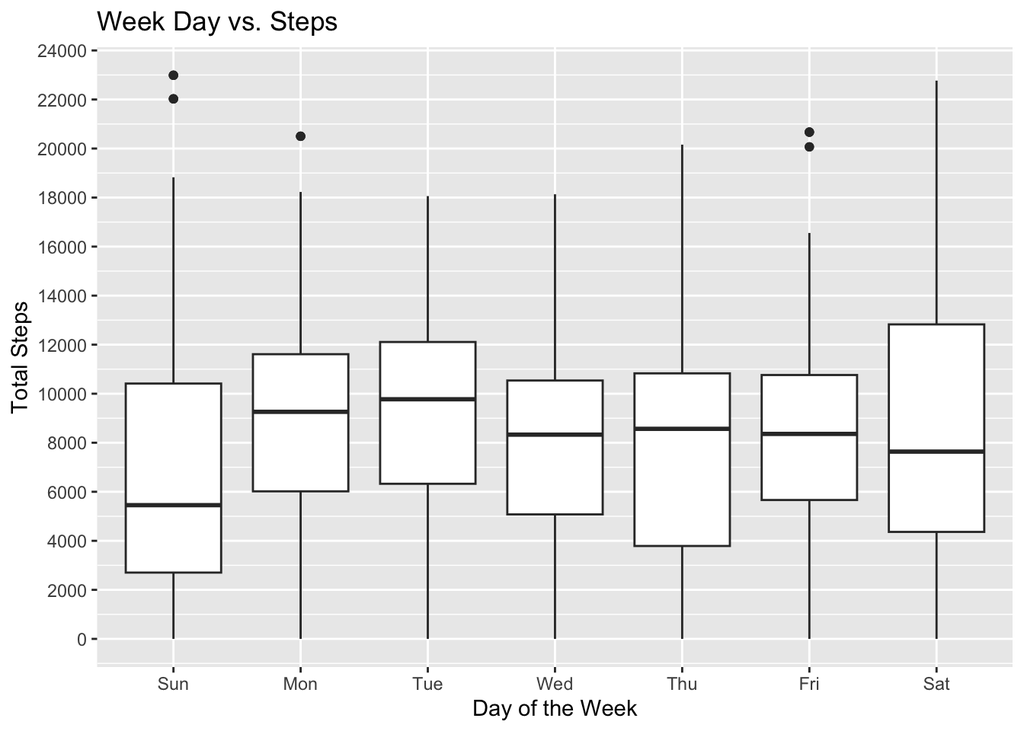

```r
plt_daily +
  geom_boxplot(mapping = aes(x = WeekDay, y = TotalSteps)) +
  xlab("Day of the Week") +
  ylab("Total Steps") +
  scale_y_continuous(breaks = seq(0, 24000, 2000)) +
  ggtitle("Week Day vs. Steps")
```

**Observations**

Saturday has the widest range in step count. On average, Monday and Tuesday have more step counts than other days. Sunday seems to be the least active day.

#### Calories

##### Scatter Plot: Steps vs. Calories

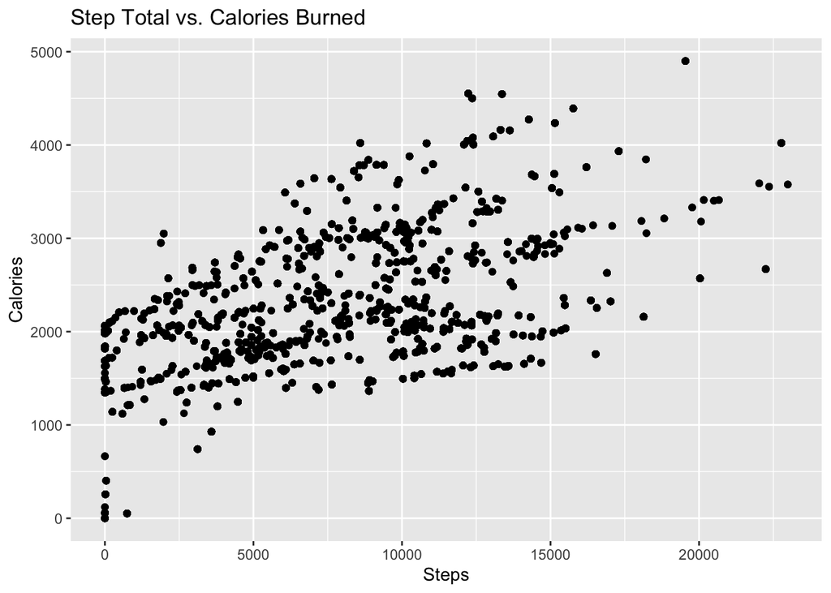

```r
plt_daily +
  geom_point(mapping = aes(x = TotalSteps, y = Calories)) +
  xlab("Steps") +
  ylab("Calories") +
  ggtitle("Step Total vs. Calories Burned")
```

**Observations**

As expected, the more steps taken the more calories burned.

##### Bar Graph: Week Day vs. Calories

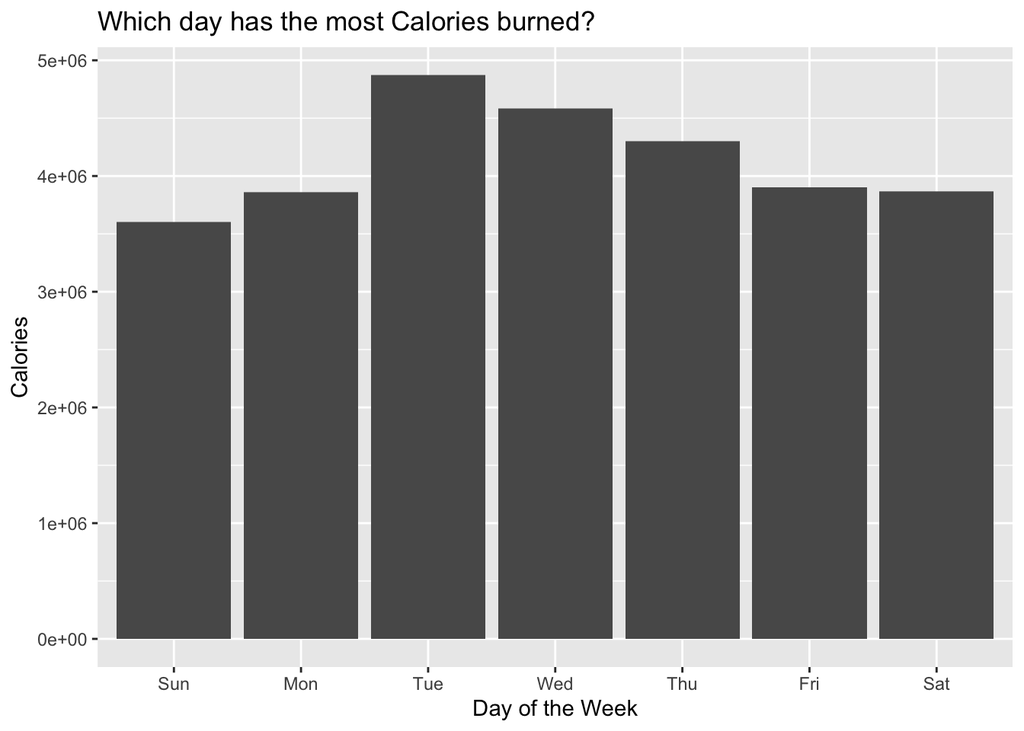

```r
plt_daily +
  geom_col(mapping = aes(x = WeekDay, y = Calories)) +
  xlab("Day of the Week") +
  ylab("Calories") +
  ggtitle("Which day has the most Calories burned?")
```

**Observations**

Similar to the bar graph comparing the day of the week and total steps, we see that Tuesday is the most active day for the participants with Sunday being the least active. It makes sense that Sunday could be the least active since this is the last day of the week and the day before the start of a new work week. However, I would have expected Saturday to be the most active day, not Tuesday.

My only guess as to why Tuesday is the most active is (perhaps) after having three days (Friday, Saturday, Sunday) of low activity, participants decided to be more active on Tuesday and Wednesday before slowing down again.

Further, it could also be the the weekend (Fri-Sun) tends to involve more leisure activities such as going to the movies, restaurants, etc. instead of activities that involve more physical moment. The high activity on Tuesday and Wednesday are then an attempt to make up for the lack of exercise from the previous weekend or anticipation of the upcoming weekend of leisure.

##### Boxplot: Week Day vs. Calories

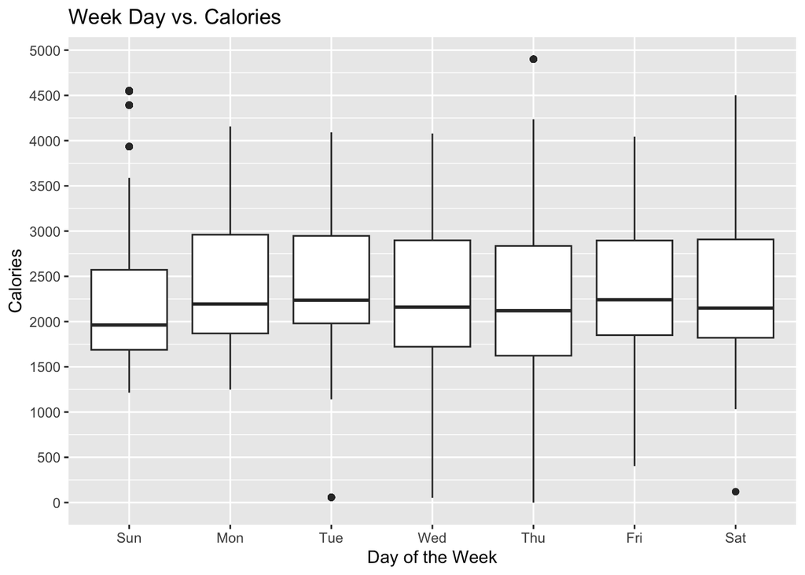

```r
plt_daily +
  geom_boxplot(mapping = aes(x = WeekDay, y = Calories)) +
  xlab("Day of the Week") +
  ylab("Calories") +
  scale_y_continuous(breaks = seq(0, 5000, 500)) +
  ggtitle("Week Day vs. Calories")
```

**Observations**

Sunday has the least amount of calories burned (with a few exceptions) while the amount of calories burned from the remaining days in the week are approximately the same. This correlates with the pattern seen previously in number of steps and calories burned throughout the week.

#### Sleep

##### Bar Graph: Week Day vs. Total Sleep

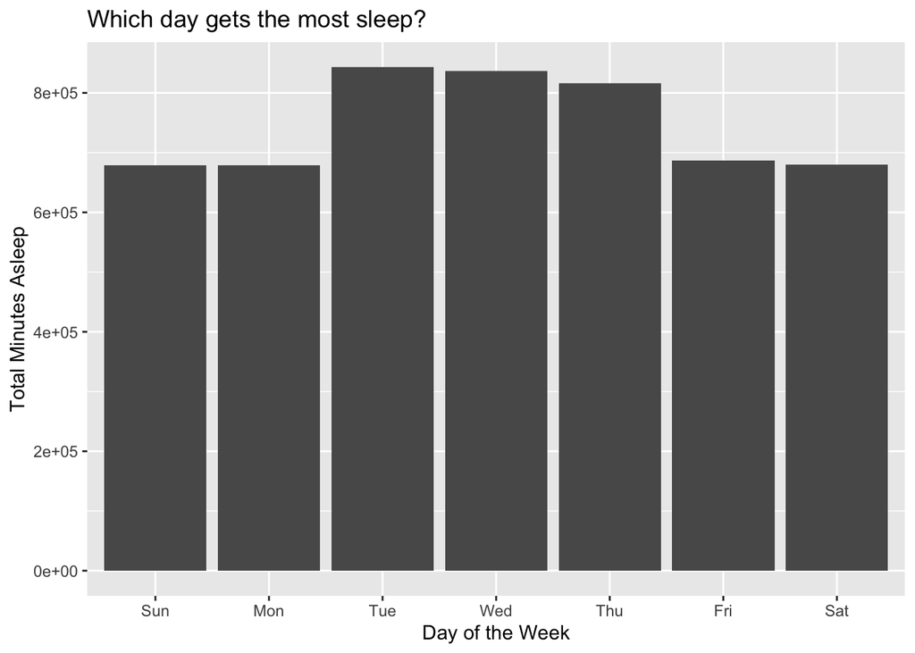

```r
plt_daily +
  geom_col(mapping = aes(x = WeekDay, y = TotalMinutesAsleep)) +
  xlab("Day of the Week") +
  ylab("Total Minutes Asleep") +
  ggtitle("Which day gets the most sleep?")
```

**Observations**

Tuesday, Wednesday, and Thursday have the most (total) amount of sleep minutes. This is the same as the days that have the most steps and calories burned. It could be that since these days required more energy they also required more sleep.

##### Bar Graph: Week Day vs. Total Time In Bed

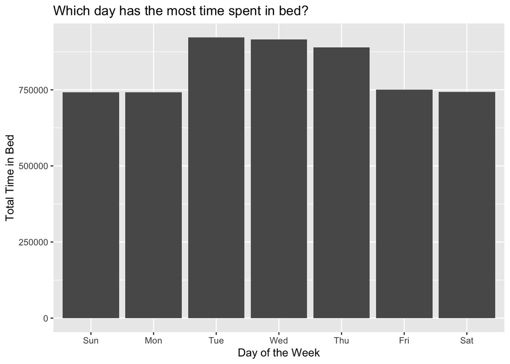

```r
plt_daily +
  geom_col(mapping = aes(x = WeekDay, y = TotalTimeInBed)) +
  xlab("Day of the Week") +
  ylab("Total Time in Bed") +
  ggtitle("Which day has the most time spent in bed?")
```

**Observations**

Tuesday, Wednesday, and Thursday have the most time spent in bed. This coincides with the observations about time spent asleep. It’s also reasonable that the more time one spends in bed, the more time they’ll be asleep.

### Summary of Observations

- Most participants have elevated heart rates between 6am and 8pm
- Most individuals fall between 100 and 200 pounds
- Only eight individuals tracked their weight, but over a 30-day period it mostly stayed the same
- Tuesday, Wednesday, and Thursday are the most active days
- Tuesday, Wednesday, and Thursday are also the days with the most sleep and time spent in bed
- Sunday is the least active day

## References

- [Data Source: Kaggle](https://www.kaggle.com/datasets/arashnic/fitbit?select=Fitabase+Data+4.12.16-5.12.16)

## Contact

- Email
- [LinkedIn](https://www.linkedin.com/in/anthonynanfito/)
- [GitHub](https://www.github.com/ananfito)
- [Portfolio](https://ananfito.github.io)